# DM—繪圖–資料視覺化

POLab

2017/05/19

[【回到首頁】](https://github.com/PO-LAB/Data-Mining)

經過上一篇的筆記，你已經明白[R的套件與函式的概念，並且知道如何使用它們](https://rpubs.com/skydome20/R-Note3-function_and_package)。想必如今你正躍躍欲試，想趕快去找一筆實際資料，運用R語言來進行分析…這樣很好！真的！

你可能已經根據前幾篇的筆記，默默開始進行練習了！

而我們今天要來學習「更實用的技巧」，也是R在推出的時候，就一直被人大力稱讚的強大功能—**繪圖(Plotting)！**

「繪圖」最主要目的，是把資料化為各式各樣的圖表(趨勢圖、長條圖、圓餅圖、箱型圖、複合式圖表…)，時常使用Excel的人，相信對這樣的動作並不陌生。

然而，你有仔細思考過，為什麼要把資料畫成圖表嗎？

事實上，這樣的動作有一個專有名詞，叫做**資料視覺化(Data Visualization)**—其牽涉的領域包括**藝術、設計、心理學、程式軟體…**毫無疑問，「資料視覺化」這個名詞，如今已經代表一門專業學科；在網路的社群上，也有來自各方人士的熱烈討論與研究。

然而，對理工背景的人來說，**設計，藝術或心理學**，就像另一個世界的語言；對人文背景的人來說，**電腦，程式或軟體**，則是無法觸及的神話…

不不不，千萬別這麼想。其實「資料視覺化」最基本、最主要的概念，只有一句話而已：**「降低資料的理解門檻」**。

在2016/03/26，[資料科學愛好者年會所舉辦的活動](http://www.slideshare.net/tw_dsconf/ss-60041639)上，台大土木系的康仕仲教授以一張圖來解釋這樣的概念：

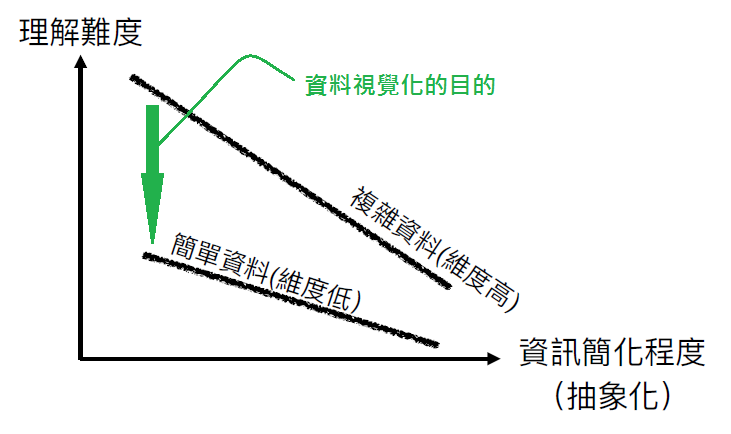

因此，「資料視覺化」可以在**不簡化資訊情況下**，**降低複雜資料的理解門檻**；也可以說，幫助我們**以較簡單的方式**，去**理解高維度(複雜)的資料**。

資料分析前，我們需要**瀏覽資料(explore data)**，以理解資料的狀態；資料分析後，我們需要把**分析結果呈現**出來，使人容易理解。

你會發現，針對以上這兩種情況，「資料視覺化」便佔了很重要的地位，對吧？因此，學好視覺化的技巧，絕對是有其必要性。

在R裡面，主要有三個強大的繪圖系統(Plotting System)，可以幫助我們輕易達成「資料視覺化」的目的，以下將會一一介紹：

# **1. Base Plotting System**

看到Base這個單字，就知道這是R最基本、最核心的繪圖系統。

不過，可不要以為基本的東西就比較陽春！事實上，光是這最基本的繪圖系統，就已經有許多功能強大的繪圖函式了！

以下都會拿R裡面，一個關於空氣品質的資料集`airquality`來進行示範：

```r
require(datasets)
head(airquality)
```

```
##   Ozone Solar.R Wind Temp Month Day
## 1    41     190  7.4   67     5   1
## 2    36     118  8.0   72     5   2
## 3    12     149 12.6   74     5   3
## 4    18     313 11.5   62     5   4
## 5    NA      NA 14.3   56     5   5
## 6    28      NA 14.9   66     5   6
```

## ‧hist()

這是畫**直方圖(Histogram)**的函式。  
當我們想要看資料裡面，各個月份(Month)有多少筆資料，可以這樣使用：

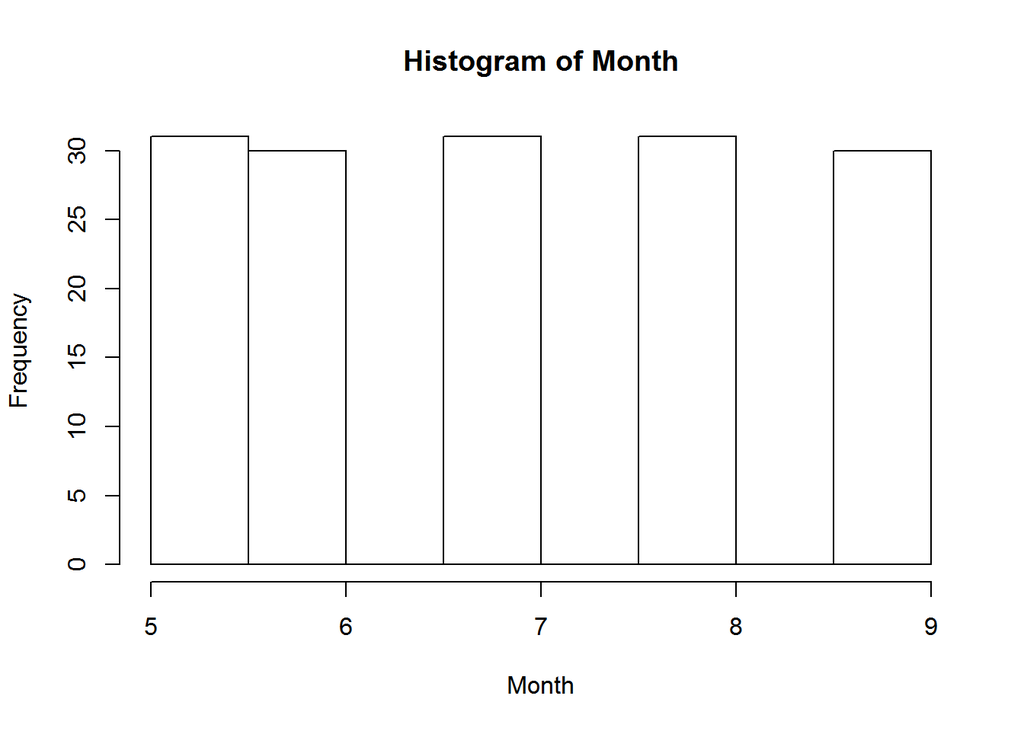

```r
hist(x=airquality$Month,
     main="Histogram of Month",         # 圖片的名稱
     xlab="Month",                      # X軸的名稱
     ylab="Frequency")                  # Y軸的名稱
```

## ‧boxplot()

這是畫**盒鬚圖(Box Plot)**的函式。  
當我們想要看資料裡面，不同月份的臭氧(Ozone)數值的分布情況，可以這樣使用：

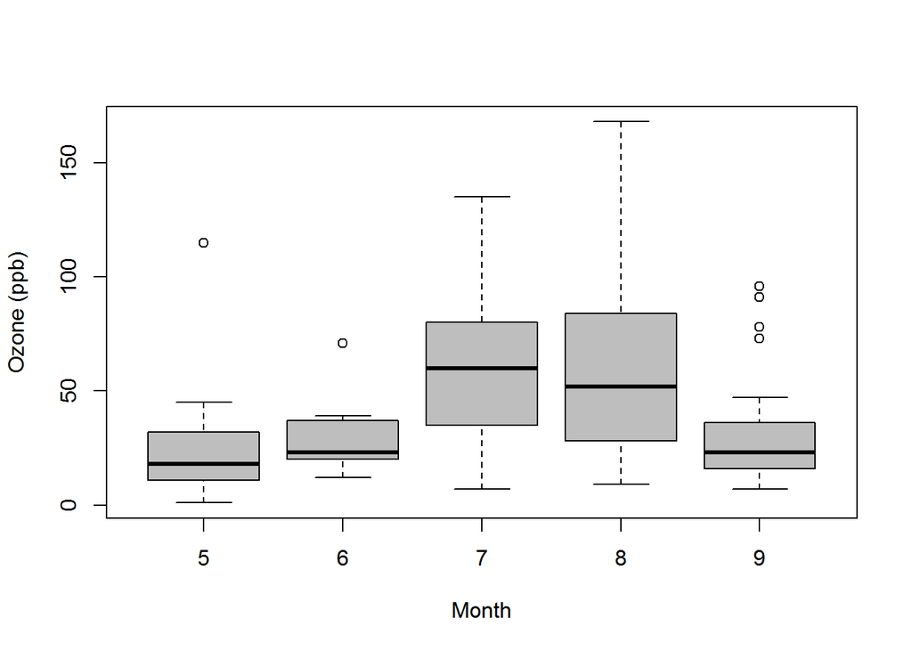

```r
boxplot(formula = Ozone ~ Month, # Y ~ X (代表X和Y軸要放的數值)
        data = airquality,       # 資料
        xlab = "Month",          # X軸名稱
        ylab = "Ozone (ppb)",    # Y軸名稱
        col ="gray")             # 顏色
```

## ‧plot()

這是畫**散布圖(Scatter Plot)**的函式。  
當我們想要看月份(Month)和氣溫(Temp)之間的關係，可以這樣使用：

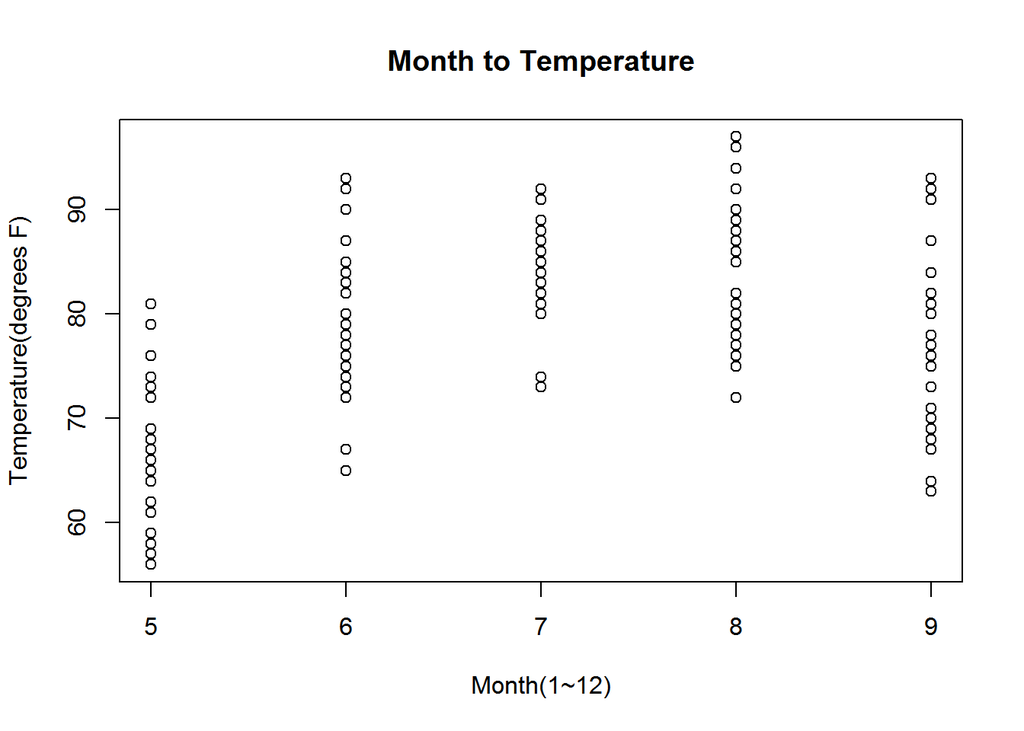

```r
plot(x=airquality$Month,            # X軸的值
     y=airquality$Temp,             # Y軸的值
     main="Month to Temperature",   # 圖片名稱
     xlab="Month(1~12)",            # X軸名稱
     ylab="Temperature(degrees F)") # Y軸名稱
```

或者，我們想要看臭氧(Ozone)和風(Wind)之間的關係：

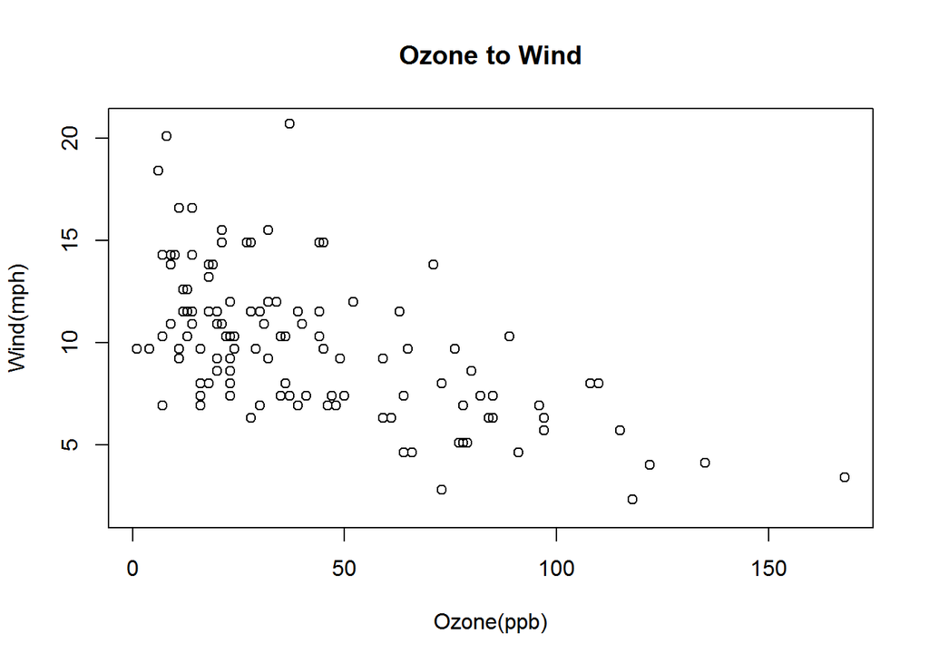

```r
plot(x=airquality$Ozone,      # X軸的值
     y=airquality$Wind,       # Y軸的值
     main="Ozone to Wind",    # 圖片名稱
     xlab="Ozone(ppb)",       # X軸的名稱
     ylab="Wind(mph)"         # Y軸的名稱
)
```

很容易，對吧？

事實上，當我們使用`plot()`函式時，代表我們其實在R裡面建立了一塊「畫布」(canvas)…對，就是藝術家作畫的那種畫布！

既然是一塊畫布，就表示我們可以隨自己的意思，在畫布上面增一筆、撇一畫，增加我們想要的東西。

因此基於這樣的觀念，在R裡面利用Base Plotting System繪圖時，可以分成「兩階段」：

**1. 創造一張圖(Creation of a plot)**

**2. 修飾這張圖(Annotation of a plot: adding lines, points, texts…)**

下面是示範的程式碼：

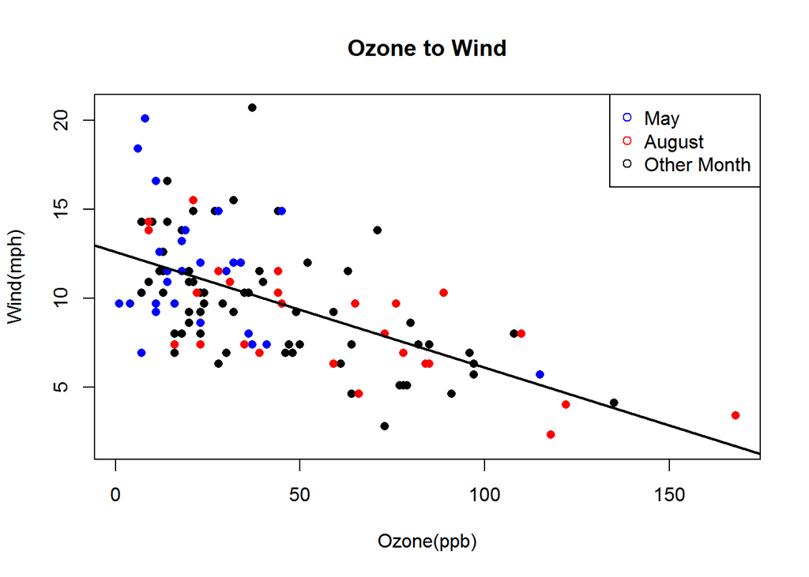

```r
# 建立一個畫布，上面已經有一張散布圖(Ozone to Wind)
plot(x=airquality$Ozone,
     y=airquality$Wind,
     main="Ozone to Wind",
     xlab="Ozone(ppb)",
     ylab="Wind(mph)",
     pch=16                  # 點的圖形
)

# 現在我們要在這張圖片中，把5月的資料點用藍色標註上去
May_data <- airquality[airquality$Month==5, ]   # 找出5月的資料
  # 標上藍色的點
points(x=May_data$Ozone,
       y=May_data$Wind,
       pch=16,                  # 點的圖形
       col="blue")              # 顏色

# 同理，也可以把8月的資料點用紅色標註上去
Aug_data <- airquality[airquality$Month==8, ]   # 找出8月的資料
  # 標上紅色的點
points(x=Aug_data$Ozone,
       y=Aug_data$Wind,
       pch=16,               # 點的圖形
       col="red")            # 顏色

# 在右上角做出標示
legend("topright",                                # 表示在右上角
       pch = 1,                                   # pch代表點的圖案
       col = c("blue", "red", "black"),           # col代表顏色
       legend = c("May", "August", "Other Month") # 顏色所對應的名稱
       )

# 我們也可以畫出回歸趨勢線
lm.model <- lm(Wind~Ozone, airquality)    # 建立一個線性回歸
  # 畫上回歸的趨勢線
abline(lm.model,
       lwd=2)     # lwd 代表線的粗細
```

(上圖是集合所有動作的成果；建議可以在自己的電腦上，一步一步慢慢執行每一行程式，就可以看見整張圖是如何變化的。)

你會發現，用`plot()`建立出一個散布圖(畫布)後，我們又運用一些函式，在畫布上面增添想要的資訊(e.g. `points()`=畫上點；`legend()`=作上標記；`abline()`=畫上線)

當然，具有類似功能的函式不只這些，這裡列出一些常用的：

| 函式 | 功能 |
| --- | --- |
| plot | 繪製散布圖(畫布) |
| lines | 把資料點用線連接 |
| points | 繪製新的資料點 |
| text | 補充文字說明在圖上 |
| title | 補充主旨 |
| mtext | 在圖外顯示大主旨 |
| axis | 增加軸的labels |

當然有的時候，我們會想要同時畫兩張圖，這時候可以使用`par()`函式：

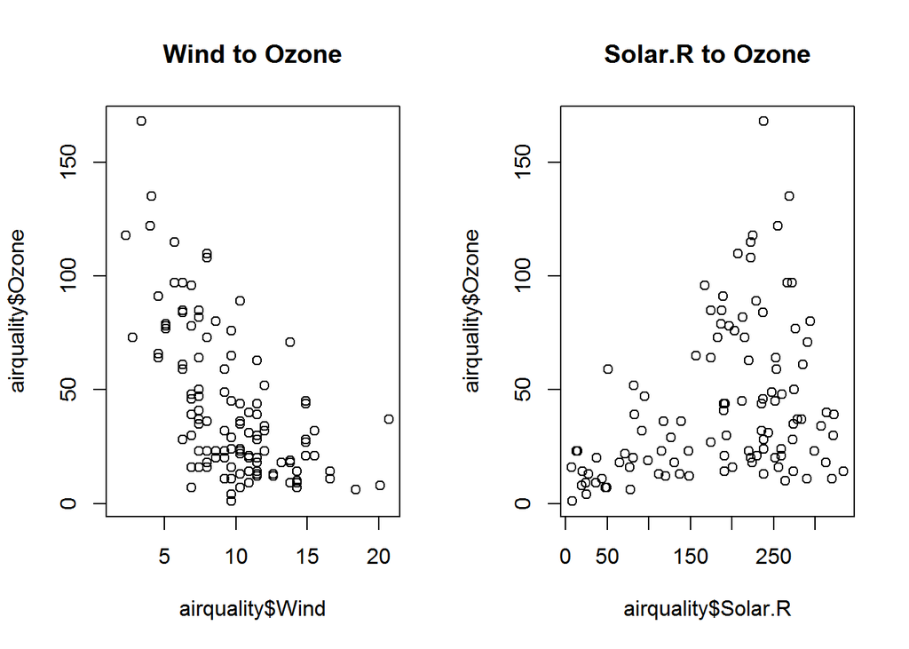

```r
# c(1,2)，表示建立一個1x2的空間，用來呈現後續的圖
par(mfrow = c(1,2))

# 第一張圖
plot(airquality$Wind, airquality$Ozone, main = "Wind to Ozone")
# 第二張圖
plot(airquality$Solar.R, airquality$Ozone, main = "Solar.R to Ozone")
```

# **2. Lattice**

這是在R裡面第二個繪圖系統。

和Base Plotting System不同的是，Lattice的繪圖概念，並不是「兩階段」，而是直接一筆在圖上繪製所有的資訊。

這裡需要注意的是，使用Lattice函式的方式，和Base Plotting System不太一樣…在Lattice裡面，函式的使用主要是這樣的型態：

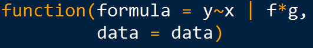

R裡面有一個公式(formula)的概念，在建模或畫圖時，用來表達x和y的值，以及條件變數：

- 在`~`左邊的，是`y`的值；在`~`右邊的，是`x`的值
- `f`和`g`代表條件變數(condition variables)，可以省略(omit)
- `data`的部分，則放置我們要繪圖的資料集

在使用Lattice繪圖之前，必須匯入`lattice`套件：

```r
require(lattice)  # 如果無法執行，請先install.packages("lattice")
```

## ‧histogram()

這是Lattice中，畫**直方圖(Histogram)**的函式。  
當我們想要看資料(airquality)中，臭氧(Ozone)在不同月份(Month)下的狀態資訊，可以這樣使用：

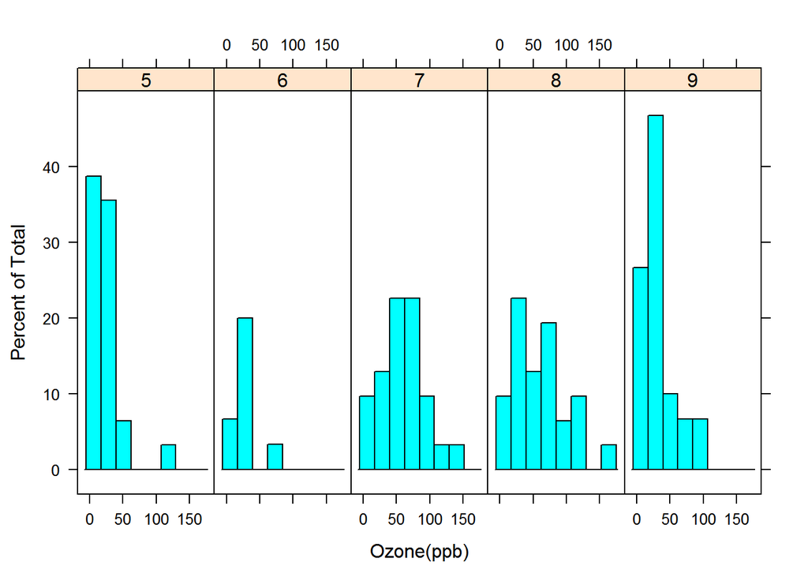

```r
# 先把月份變成類別變數
airquality$Month <- as.factor(airquality$Month)

# 繪圖
histogram(x= ~ Ozone | Month,  # 根據月份(Month)的條件，繪製臭氧(Ozone)的直方圖
          data=airquality,
          xlab="Ozone(ppb)",
          layout=c(5,1))       # 以5x1的方式呈現圖表
```

## ‧bwplot()

這是畫**盒鬚圖(Box Plot)**的函式。  
當我們想要看資料裡面，不同月份的臭氧(Ozone)數值的分布情況，可以這樣使用：  
(可以和`boxplot()`的圖對照)

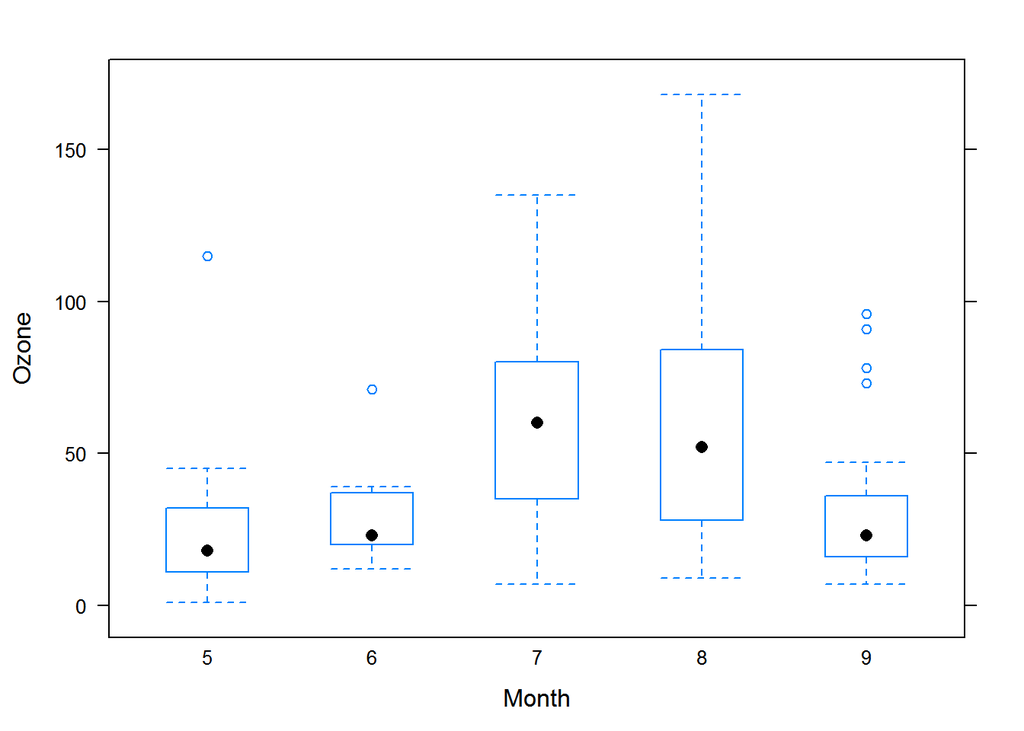

```r
bwplot(x = Ozone ~ Month,      # 把Month放在X軸，Ozone放在Y軸
       data = airquality,
       xlab = "Month"
       )
```

## ‧densityplot()

這是畫**機率密度圖**的函式。  
當我們想要看資料裡面，臭氧(Ozone)的機率密度分布關係，可以這樣使用：

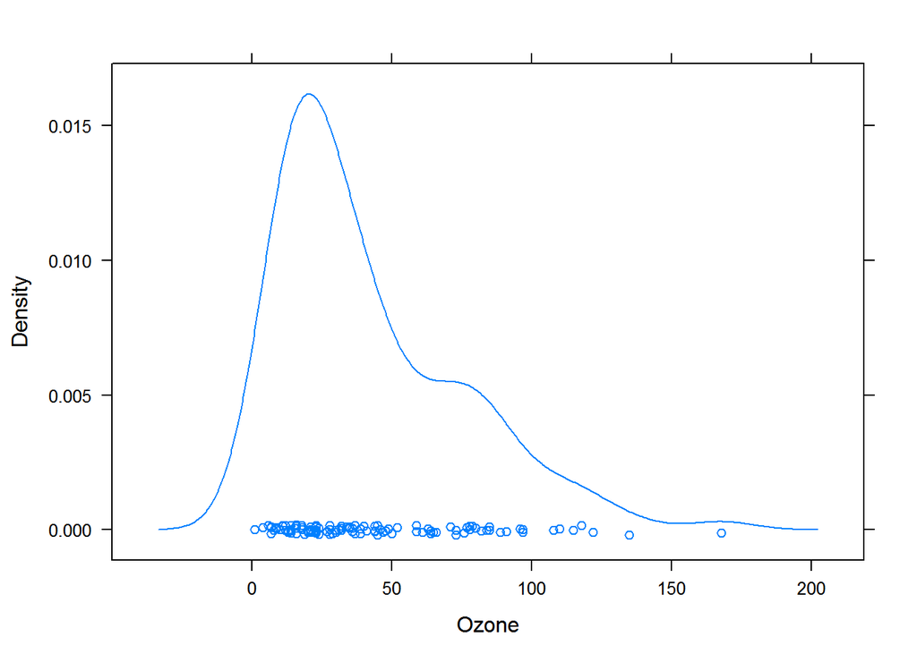

```r
# 把Ozone放在x的值；當然，可以增加月份的條件( ~ Ozone | Month)
densityplot( ~ Ozone ,
            data=airquality
            )
```

## ‧cloud()

這是畫**3D圖**的函式。  
當我們想要看資料裡面，不同月份下，臭氧(Ozone)、氣溫(Temp)和風(Wind)之間的關係，可以這樣使用：

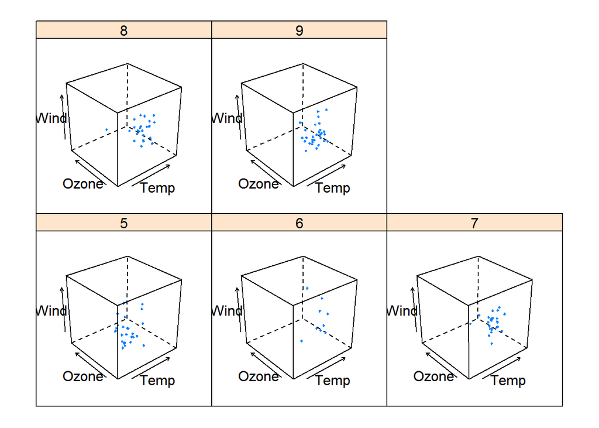

```r
# Wind放在Z軸，Temp和Ozone放在X和Y軸，根據Month條件分別繪圖
cloud(x=Wind~Temp+Ozone | Month,
       data=airquality
      )
```

## ‧xyplot()

這是畫**散布圖(Scatter Plot)**的函式。  
當我們想要看不同月份(Month)之間，氣溫(Temp)和風(Wind)之間的關係，可以這樣使用：

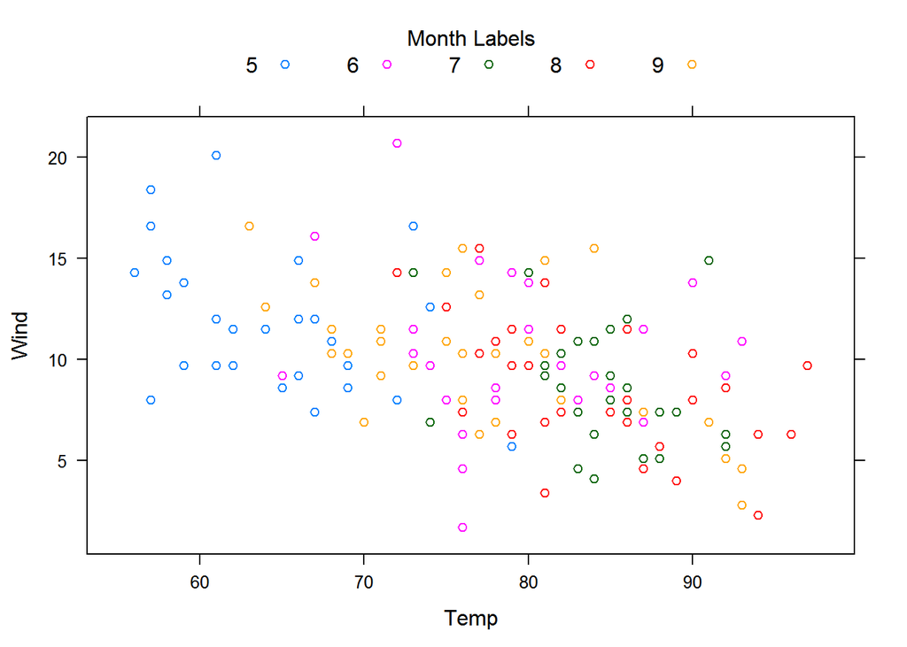

```r
xyplot(x=Wind~Temp,         # Wind放在Y軸，Temp放在X軸
       data=airquality,
       group = Month,       # 根據Month，把資料點用顏色區分開來

       # auto.key參數，表示設定標籤與其他資訊
       auto.key=list(space="top",          # 位置在上方
                     columns=5,            # 1x5的方式呈現標籤
                     title="Month Labels", # 標籤名稱
                     cex.title=1)          # 標籤字體大小
       )
```

還記得在Base Plotting System裡面，當我們畫完散布圖後，可以再隨意添加各種資訊上去嗎？可惜的是，這在Lattice是行不通的。

「一次把所有資訊繪在圖上」，是Lattice的精髓。而要達成這樣的目的，我們要學習一個叫`panel function`的概念。

簡單來說，`panel function`是用來**控制所有發生在圖表內的資訊**，只是在寫法上會稍嫌困難一些。下面會舉兩個例子，幫助大家理解`panel function`的運用與概念：

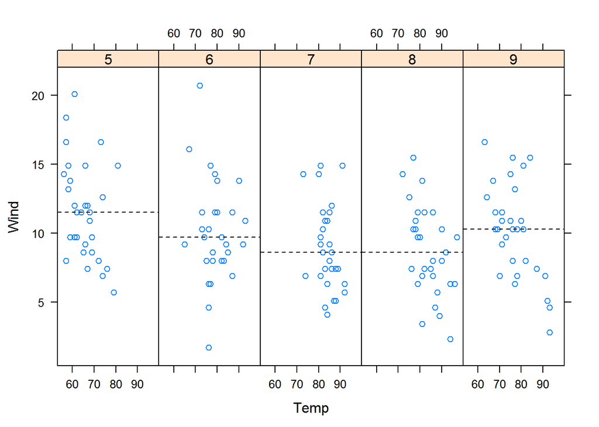

```r
# 目的:我們想要在散布圖中，畫出標示出中位數的線 #

xyplot(x=Wind~Temp | Month,  # Wind放在Y軸，Temp放在X軸，並根據Month條件分別繪圖
       data=airquality,
       layout = c(5,1),      # 以5x1的方式呈現圖

       # 在這裡，我們要使用panel function，畫出中位數的線
       panel=function(x,y){
           # function的寫法，會用大括號包起來，裡面表示要進行的動作：
           # 在這個panel function裡面，我們進行了兩個動作
           panel.xyplot(x, y)                    # 1.繪製x-y的散布圖
           panel.abline(h = median(y), lty = 2)  # 2.標示出中位數的線段
       }

)
```

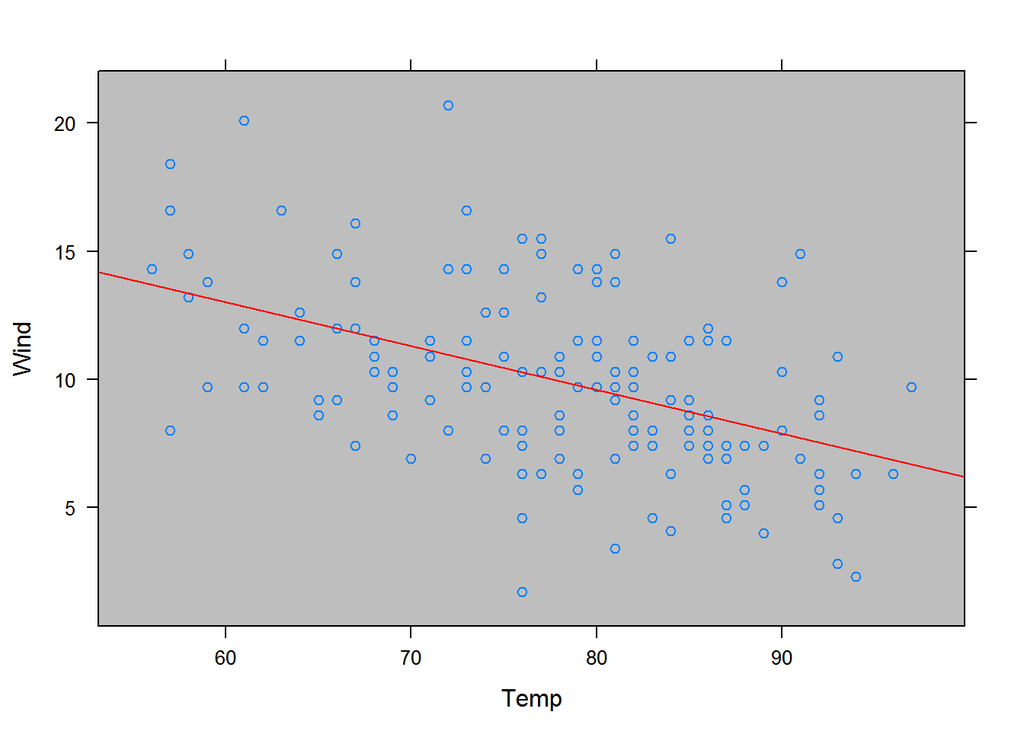

```r
# 目的:我們想要在散布圖中，畫出線性回歸的趨勢線 #

xyplot(x=Wind~Temp ,         # Wind放在Y軸，Temp放在X軸
       data=airquality,

       # 在這裡，我們要使用panel function，畫出線性回歸的趨勢線
       panel=function(x,y){
           # function的寫法，會用大括號包起來，裡面表示要進行的動作：
           # 在這個panel function裡面，我們進行了三個動作
           panel.fill(col="gray")         # 1.改變背景顏色(gray)
           panel.xyplot(x, y)             # 2.繪製x-y的散布圖
           panel.lmline(x, y, col="red")  # 3.畫出線性回歸的趨勢線
       }

)
```

[這個網站](http://www.magesblog.com/2012/12/changing-colours-and-legends-in-lattice.html)有更多關於Lattice繪圖的技巧(顏色、標籤…)，有興趣的歡迎參考。

# **3. ggplot2**

接下來要介紹的，是在R裡面最受歡迎的第三方繪圖套件：**ggplot2**。

`ggplot2`的繪圖概念，又和上面兩者不一樣，是基於**Grammar of Graphics**的想法，直譯來說，就是「圖形的文法」。

這是一個十分抽象的概念。簡單來說，就是當你在用`ggplot2`繪圖的時候，要思考圖形(graphics)中的**「名詞(noun)」、「動詞(verb)」、「形容詞(adjective)」**…就是這樣的概念！

在`ggplot2`中，繪圖的文法包括兩個主要屬性：

- Aesthetic attributes (美學表現)：包括「顏色、形狀、點的大小與線的粗細」等…
- Geometric objects (幾何屬性)：包括「點、線、盒狀圖、直條圖」等…

此外，還有其他次要屬性：

- Facets：提供在同一張圖內做多個子圖的方法，只要使用Faceting功能設定子圖分類的依據參數即可。
- Stats：將資料做統計轉換。
- Scales：修改點線的顏色、形狀、xy軸的範圍等

使用ggplot2時，需要匯入`ggplot2`的套件，並且根據以下步驟進行繪圖：

## ‧qplot()

這是`ggplot2`裡面比較簡易的函式，使用上很像`plot()`的觀念，不同的是，我們可以單純利用這個函式，改變其中`geom`的參數，就能畫出**直方圖、散佈圖、合鬚圖**…等等圖形。

### **直方圖(histogram)**

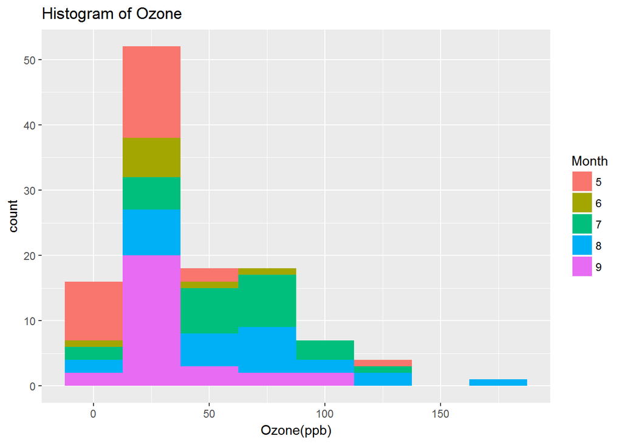

```r
require(ggplot2)
qplot(x=Ozone,
      data=airquality,
      geom="histogram",             # 圖形=histogram
      main = "Histogram of Ozone",
      xlab="Ozone(ppb)",
      binwidth = 25,                # 每25單位為一區隔
      fill= Month                   # 以顏色標註月份，複合式的直方圖
      )
```

### **散布圖(scatter plot)**

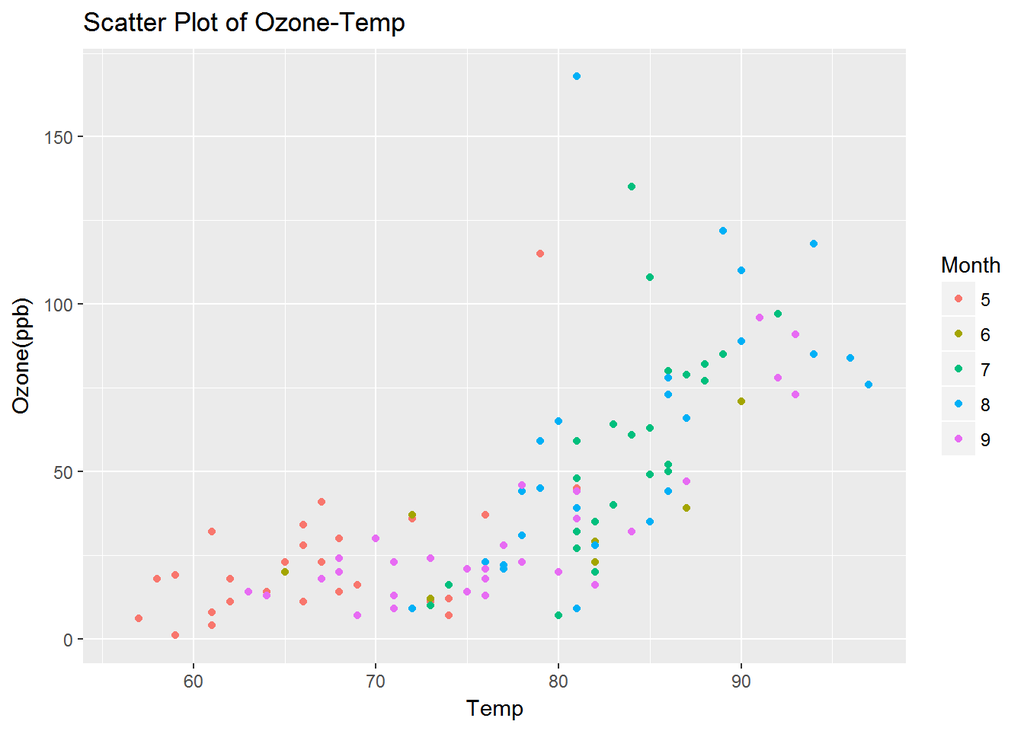

```r
qplot(x=Temp,
      y=Ozone,
      data=airquality,
      geom="point",                         # 圖形=scatter plot
      main = "Scatter Plot of Ozone-Temp",
      xlab="Temp",
      ylab="Ozone(ppb)",
      color= Month                          # 以顏色標註月份，複合式的散布圖
      )
```

### **機率密度圖(density plot)**

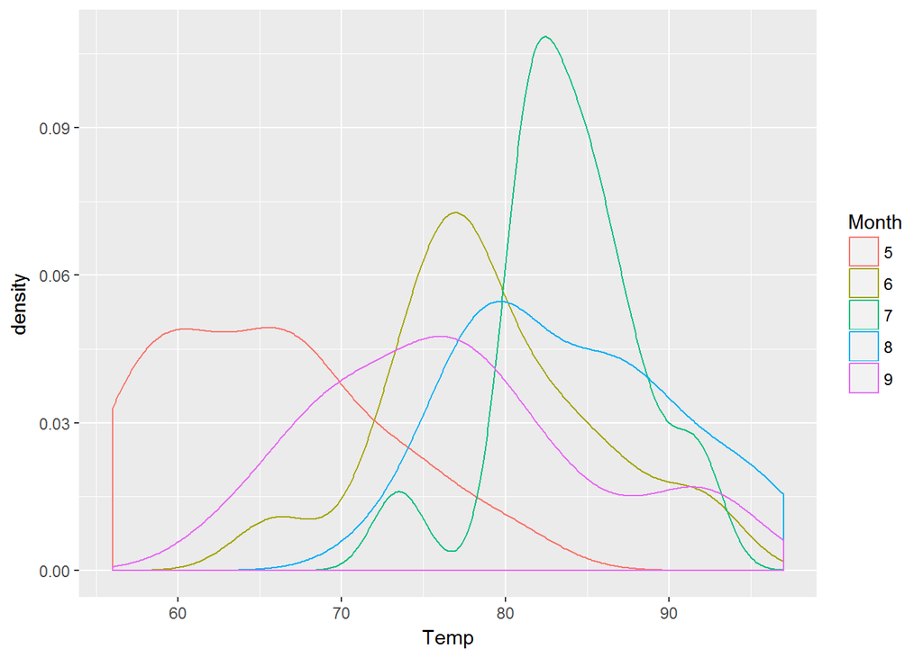

```r
qplot(x=Temp,
      data=airquality,
      geom="density",        # 圖形=density
      xlab="Temp",
      color= Month           # 以顏色標註月份，複合式的機率密度圖
)
```

### **合鬚圖(boxplot)**

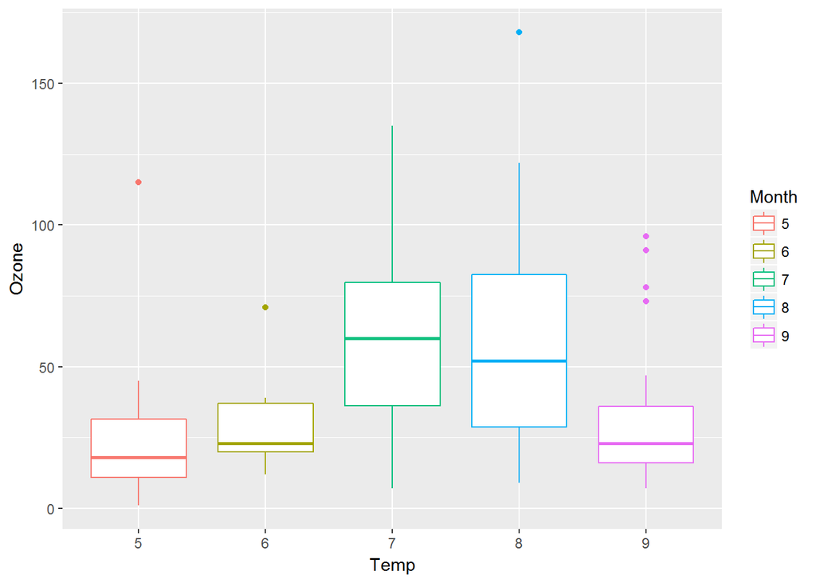

```r
qplot(x=Month,
      y=Ozone,
      data=airquality,
      geom="boxplot",       # 圖形=boxplot
      xlab="Temp",
      color= Month          # 以顏色標註月份，複合式的合鬚圖
)
```

`qplot()`裡面因為有許多內建的參數，因此使用起來，會讓人覺得很像是`plot()`或Lattice的繪圖函式。

然而，卻也因為是內建的參數，有時候在使用`qplot()`時，會覺得有些受到限制。

因此，在`ggplot2`裡面，有另外一個函式叫做`ggplot()`，就是使用**「圖形的文法」**來進行繪圖。

比起`qplot()`，`ggplot()`需要自己進行各種設定(美學/幾何)，雖然學習上比較複雜一點，卻也因此更加有彈性(flexible)和客製化(customized)的表現。

## ‧ggplot()

雖然說是「圖形的文法」，但概念上和`plot()`的兩階段流程十分相似，只是這裡變成「三階段流程」：

1. 準備好資料，用`ggplot()`建構出圖形的「畫布」(canvas)。
2. 設定**Aesthetic attributes**：使用`aes(x, y, ...)`指定。
3. 指定**Geometric objects**：(`geom_histogram()`、`geom_point()`、`geom_line()`、`geom_polygon()`、`geom_errorbar()`…)。

(*關於第二點的「美學表現」，我們可以在建構畫布(`ggplot()`)時設定，也可以在決定幾何圖形(`geom()`)時設定，十分彈性。)

在這裡，以airquality為例子，先單純準備好一個畫布：

```r
# 準備一個畫布，資料集=airquality
canvas <- ggplot(data=airquality)
```

由於用`ggplot()`的時候，並不會輸出圖形，只是準備好畫布(canvas)而已，因此接下來我們要用`geom()`，決定要繪製何種圖表。

### **直方圖(histogram)**

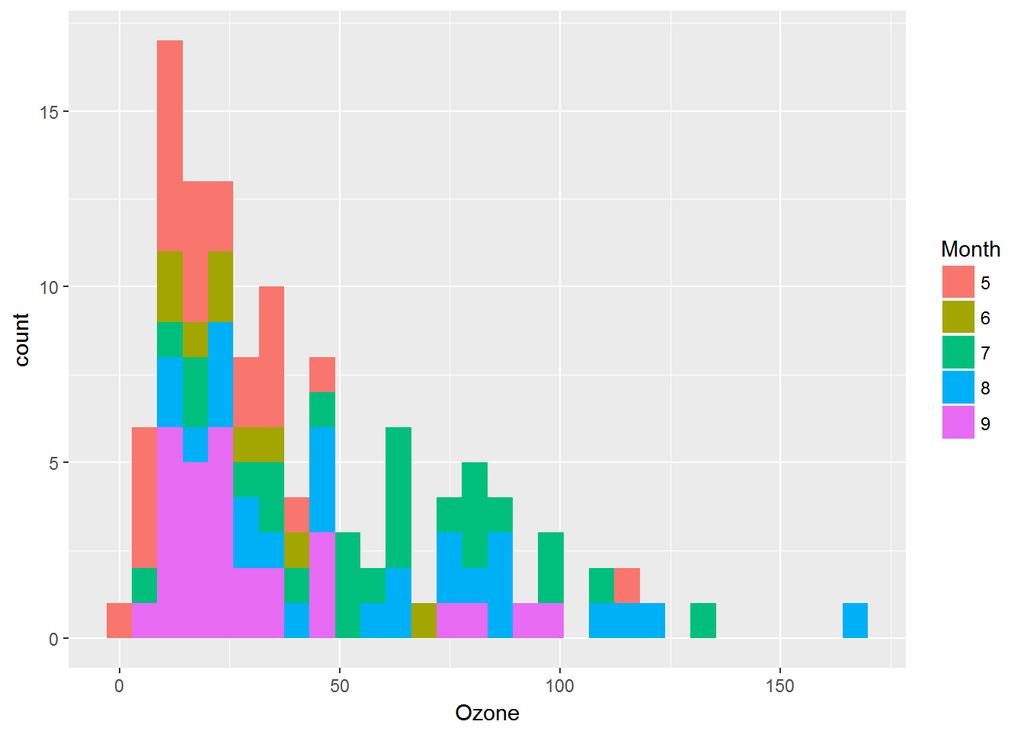

```r
# 方才準備的畫布
canvas +
    # 以直方圖的圖形呈現資料
    geom_histogram(aes(x=Ozone,     # X 放Ozone
                       fill=Month   # 根據月份顯示不同的顏色
                       )
                   )
```

而當我們想要每一個月份，分別畫一張直方圖的話，可以使用`facet()`函式。

其參數的形式`vertical ~ horizontal`，表示圖片是要以垂直/水平的方向呈現。

(更多：http://www.cookbook-r.com/Graphs/Facets_%28ggplot2%29/)

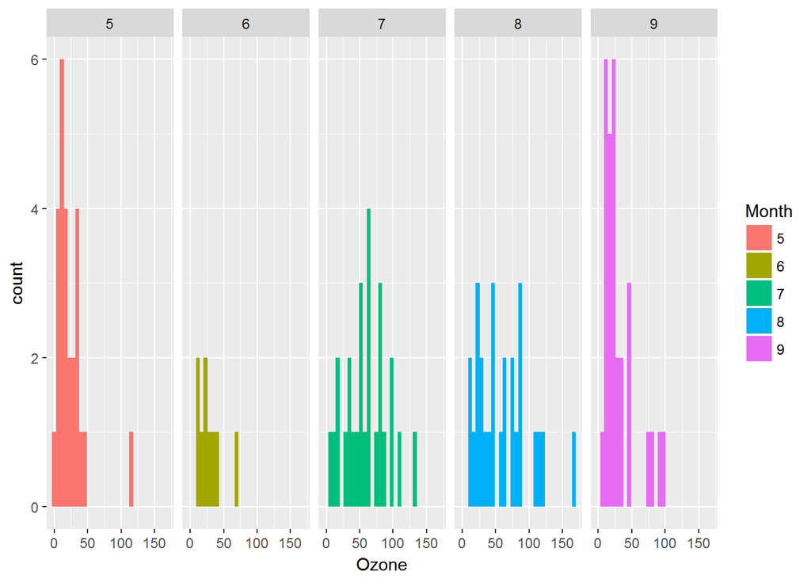

```r
# 方才準備的畫布
canvas +
    # 以直方圖的圖形呈現資料
    geom_histogram(aes(x=Ozone,
                       fill=Month)  # 以粉紅色填滿
                   ) +

    # 用facet()，分別各畫一張各月份的直方圖
    facet_grid(.~Month)   # 因為Month放在右邊，故圖片以水平方向呈現
```

這裡有個觀念十分重要，我們其實是用`+`符號，來連接不同的圖層(canvas、幾何圖表、美學表現)，所有圖層最後會呈現在圖表上。

### **散布圖(scatter plot)**

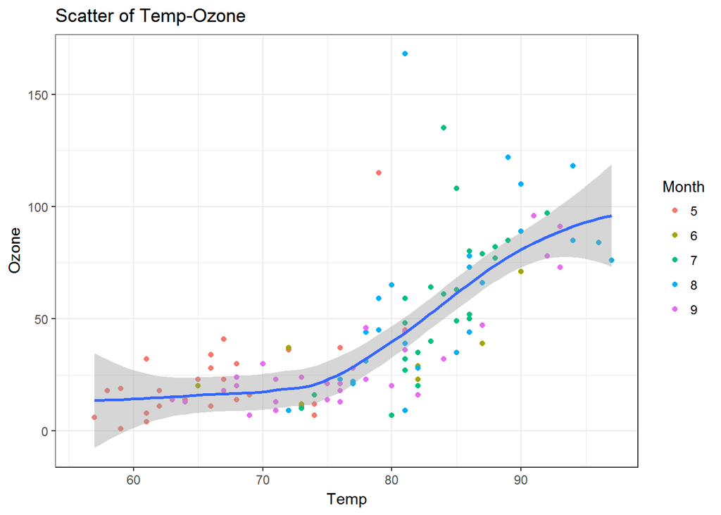

```r
# 準備畫布
ggplot(data=airquality) +

    # 散布圖對應的函式是geom_point()
    geom_point(aes(x=Temp,  # 用aes()，描繪散布圖內的各種屬性
                   y=Ozone,
                   main="Scatter Plot of Ozone-Temp",
                   color=Month)
               ) +
    # 用geom_smooth()加上趨勢線
    geom_smooth(aes(x=Temp,
                    y=Ozone)) +

    # 用labs()，進行文字上的標註(Annotation)
    labs(title="Scatter of Temp-Ozone",
         x="Temp",
         y="Ozone") +

    # 用theme_bw(background white)，改變主題背景成白色
    # 更多背景設定： http://docs.ggplot2.org/current/ggtheme.html
    theme_bw()
```

我們也可以改用畫線的方式，呈現資料：

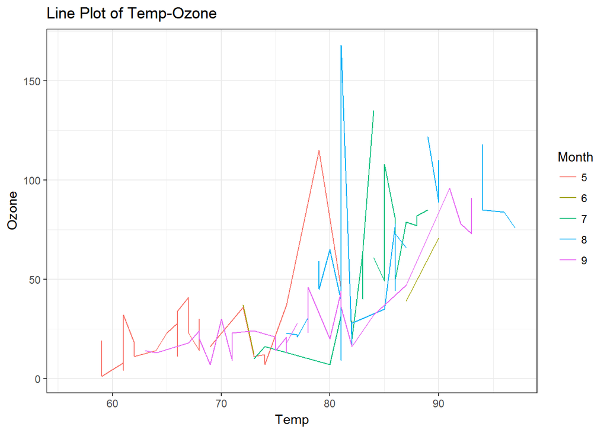

```r
ggplot(data=airquality) +

    # 要畫線的話，對應的函式是geom_line()
    geom_line(aes(x=Temp,
                   y=Ozone,
                   color=Month)
               ) +

    # 用labs()，進行文字上的標註(Annotation)
    labs(title="Line Plot of Temp-Ozone",
         x="Temp",
         y="Ozone") +

    theme_bw()
```

也可以把上面那兩張圖，合併在一起：

### **複合式圖表**

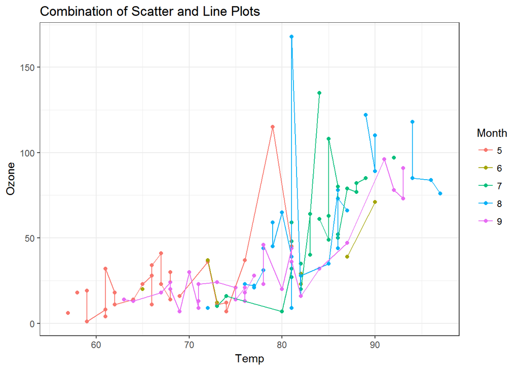

```r
# 準備畫布
ggplot(data=airquality) +

    # 散布圖對應的函式是geom_point()
    geom_point(aes(x=Temp,
                   y=Ozone,
                   main="Scatter Plot of Ozone-Temp",
                   color=Month)
               ) +
    # 要畫線的話，對應的函式是geom_line()
    geom_line(aes(x=Temp,
                   y=Ozone,
                   color=Month)
               ) +

    # 用labs()，進行文字上的標註(Annotation)
    labs(title="Combination of Scatter and Line Plots",
         x="Temp",
         y="Ozone") +

    theme_bw()
```

### **圓餅圖**

要用`ggplot2`畫圓餅圖，要先畫出bar plot，再沿著y軸進行轉軸：

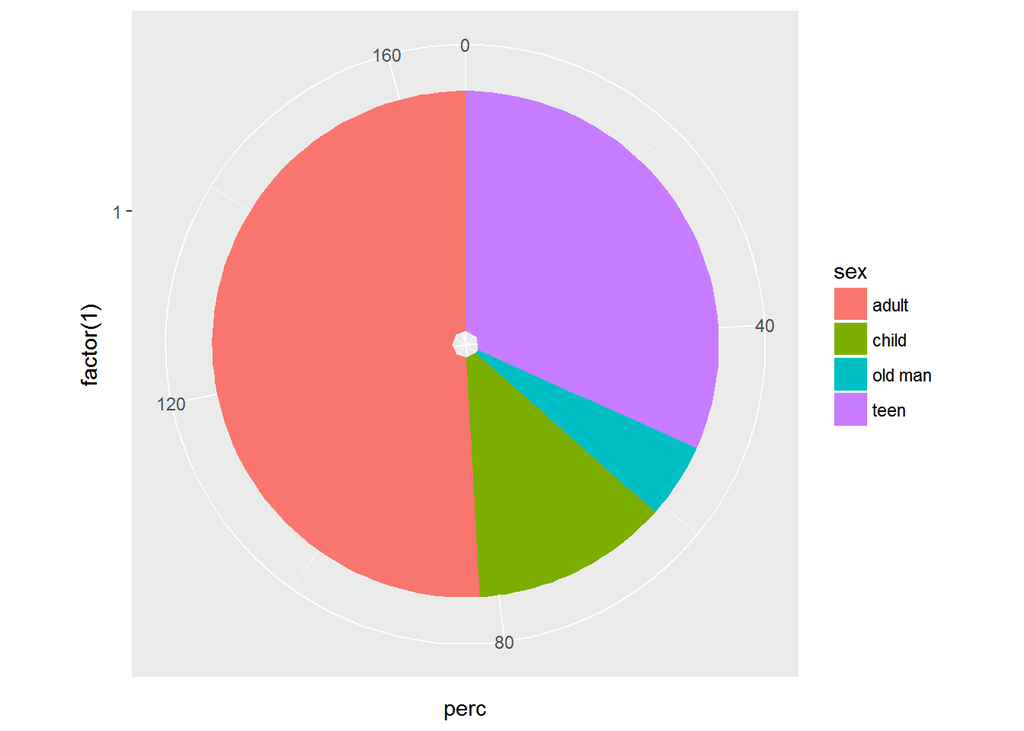

```r
# 自己定義一筆新的資料
df <- data.frame(sex=c("child", "teen", "adult", "old man"),
                 perc=c(21,53,85,8)
                 )

#準備畫布
ggplot(data=df) +

    # 先畫bar plot
    geom_bar(aes(x=factor(1),
                 y=perc,
                 fill=sex),
             stat = "identity"
             ) +

    # 再沿著Y，轉軸成圓餅圖
    coord_polar("y", start=0)
```

# **4. 儲存圖片成png,jpeg,bmp…**

如今，你已經學會如何運用R的三個繪圖系統，來畫出自己想要的圖。

但當你用R畫完圖以後，它只存在於R裡面，無法自由存取。因此，我們必須把圖片儲存到自己的電腦上，這才是我們最終的目的。

要用R把圖片輸出其實很簡單，例如我們要把畫好的圖片輸出成.png的型態，那我們就在前後加上`png()`和`dev.off()`，把我們繪圖的程式碼包起來，就像這樣：

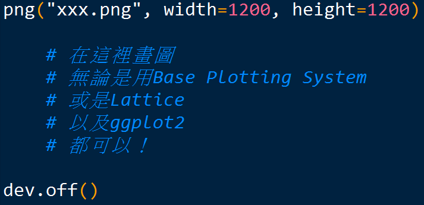

(jpeg對應的`jpeg()`，bmp對應的是`bmp()`，pdf對應的是`pdf()`)

我們拿上面ggplot2畫的「複合式圖表」對它進行輸出，程式碼就像這樣：

```r
#表示要儲存成png的格式
png("Combination of Plots.png", width=600, height=600)

    ##複合式圖表 ##
    ggplot(data=airquality) +

        # 散布圖對應的函式是geom_point()
        geom_point(aes(x=Temp,
                       y=Ozone,
                       main="Scatter Plot of Ozone-Temp",
                       color=Month)
        ) +
        # 要畫線的話，對應的函式是geom_line()
        geom_line(aes(x=Temp,
                      y=Ozone,
                      color=Month)
        ) +

        # 用labs()，進行文字上的標註(Annotation)
        labs(title="Combination of Scatter and Line Plots",
             x="Temp",
             y="Ozone"
        ) +

        theme_bw()

dev.off() #最後要關掉輸出圖片裝置
```

# **總結**

這篇筆記由簡到難，介紹了三種R的繪圖系統。我們可以用不同的繪圖系統，去繪製相同效果的圖表(當然，外觀上可能會不太一樣)。雖然內容很多，學起來不太容易，不過人畢竟是視覺的生物，好好掌握資料視覺化(繪圖)的技巧，在資料分析中是一項很重要的能力。

下一篇筆記，我們開始真正進入資料分析的過程：拿一筆實際的資料，進行一次**簡單、卻完整**的分析(包含預處理、視覺化、建模、分析報表…)。  
It’s still a long way to go~

# **(額外)資料視覺化的資源**

- 台灣資料科學愛好者年會的演講：[[資料視覺化之理論、賞析與實作—投影片]](http://www.slideshare.net/tw_dsconf/ss-60041639) (2016/03/26)
- [[資料視覺化]](http://blog.infographics.tw/) ，與其[[臉書專頁]](https://www.facebook.com/data.visualize/)
- [[用數據看台灣]](https://www.facebook.com/taiwanstat/?fref=ts)